# UK Weather Report

H MacGinty

June 2023

### Abstract

In sum, the weather in London, and the UK in general, is terrible.

# Introduction

I must convince my friend to stay in Cape Town and not move to London based on how awful the weather is there. We all know that Cape Town has the best climate which makes it so difficult to live anywhere else.

# Data

I have data on both London and the UK in general. I first examine London before assessing the overall weather in the UK.

# London

Firstly, I examine data on London specifically, as this is likely where my friend would live and work.

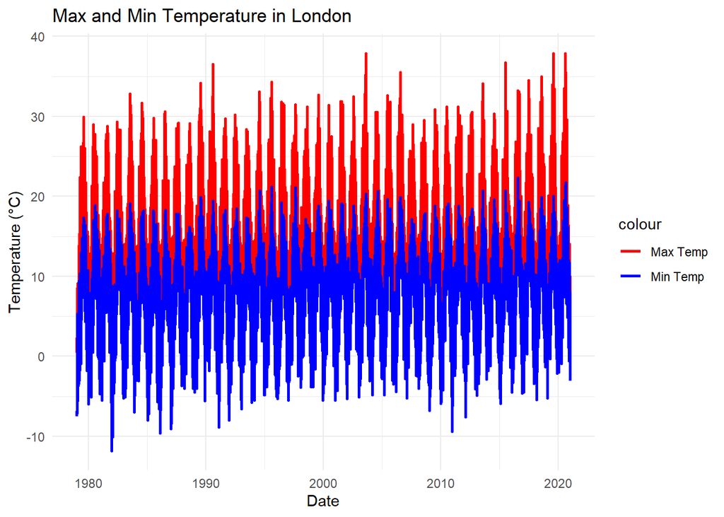

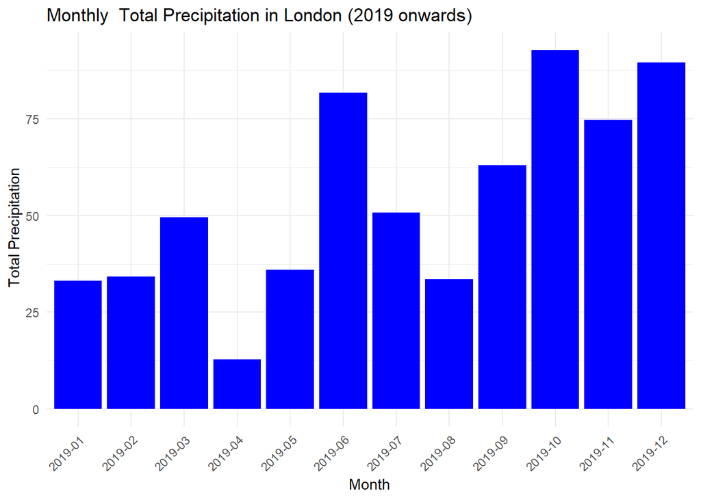

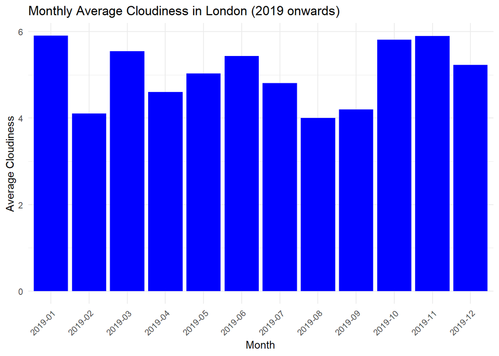

Thirdly, it is cold! In some months of the year, the average minimum temperature is below 0 degrees.

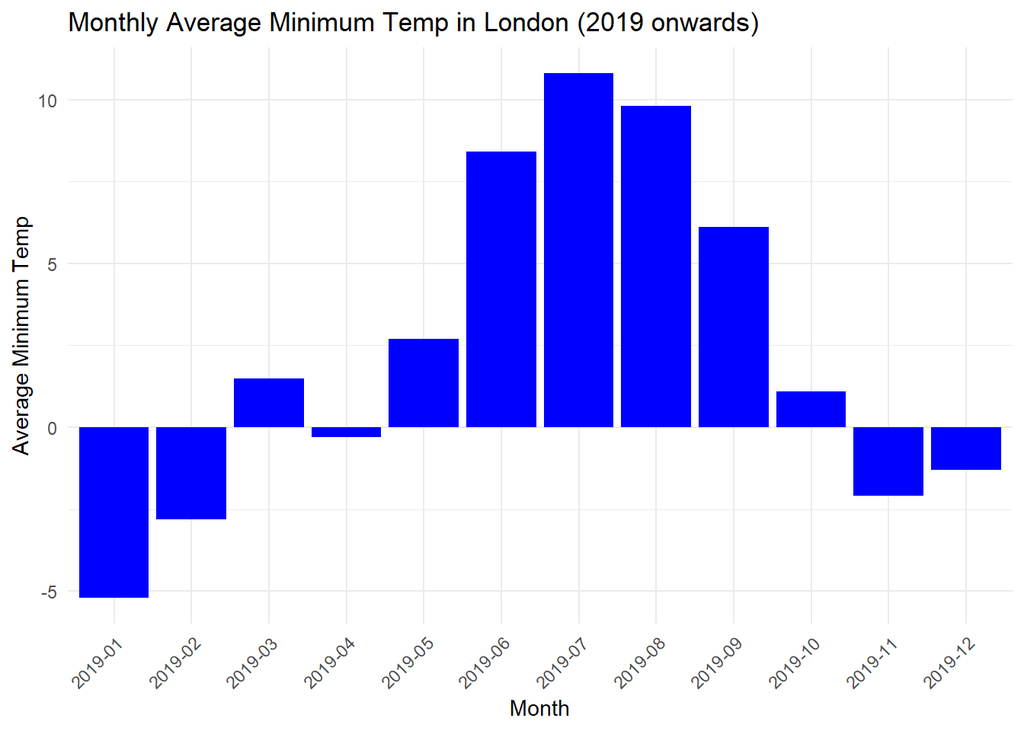

I have also included some tables for my friend to see how miserable the weather is in London.

The average temperature is around 12 degrees Celsius each year. It can often be as cold as -5 degree Celsius.

Table 1: Temperature Range

| Year | Min Temp | Max Temp | Avg Temp |
| --- | --- | --- | --- |
| 2015 | -5.9 | 36.7 | 12.13416 |
| 2016 | -4.6 | 33.2 | 11.90137 |
| 2017 | -4.5 | 34.5 | 12.07750 |
| 2018 | -5.4 | 35.0 | 12.52932 |
| 2019 | -5.2 | 37.9 | 12.19397 |

Again, the average rain is substantial and even though there is some sunshine, on average, it is matched by lots of cloudiness.

Table 2: Sunshine, Cloudiness and Rain

| Year | Average Sun | Average Cloudiness | Average Rain |
| --- | --- | --- | --- |
| 2015 | 4.131956 | 4.771350 | 51.6 |
| 2016 | 4.000822 | 5.202740 | 27.0 |
| 2017 | 3.853333 | 5.361111 | 36.8 |
| 2018 | 4.670685 | 4.901370 | 31.8 |
| 2019 | 4.235890 | 5.054794 | 31.8 |

# UK

Even if my friend does not move to London, it is cold everywhere in the UK. I plotted the yearly average temperature in the UK. The average temperature does not rise above 10-11 degrees. It has been like this since 1880 - its not going to change anytime soon.

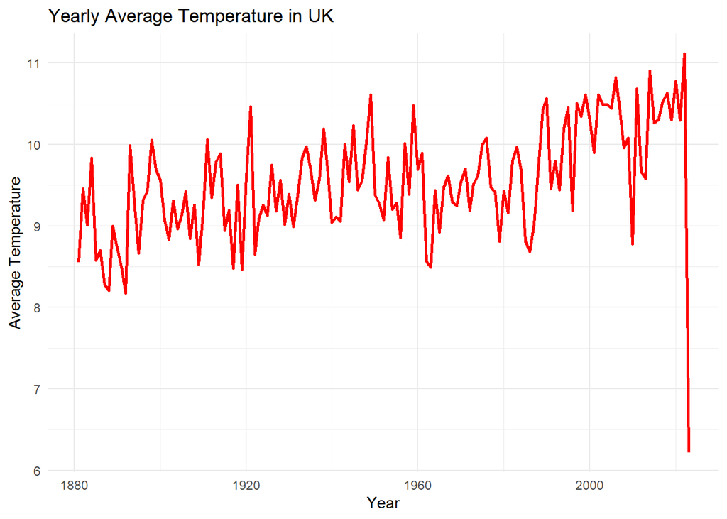

[figure not shown]

# Conclusion

The UK is a terrible place to move to if one dislikes the cold, lack of sunshine, and rain.